# PCA analysis of functional composition among rodent genomes

Santiago Herrera-Alvarez

September 9, 2018

### The idea behind the PCA

PCA based on content and size of gene families has been shown to reflect important evolutionary splits between groups or clades of animals (non-bilaterian and bilaterian: Simakov et al., 2013; deuterostomes and protostomes: Albertin et al., 2015).

Following Simakov et al. (2013), functional repertoires of the genomes were represented in a multidimensional space, where each dimension corresponds to a particular gene family. A principal component analysis (PCA) was conducted using the prcomp function in R (R Development Core Team, 2008) on the count of the number of genes in each gene family as identified by PANTHER. The coordinate of a species??? genome along each dimension represents the number of genes that it contains with the corresponding gene family normalized by the total number of genes in that particular species.

In the folder *PANTHER_output* are the outputs of PANTHER families annotations for each genome. The annotations were performed using the protocol for large-scale gene function analysis with PANTHER (Mi et al., 2013).

```r
# Read each list of families as a separate file
BMRat <- as.character(read.csv("../PANTHER_output/BMRat.faa_PANTHER.txt", h = FALSE,
    sep = "\t")$V2)
Capybara <- as.character(read.csv("../PANTHER_output/Capybara.faa_PANTHER.txt", h = FALSE,
    sep = "\t")$V2)
Castor <- as.character(read.csv("../PANTHER_output/Castor.faa_PANTHER.txt", h = FALSE,
    sep = "\t")$V2)
Chinchilla <- as.character(read.csv("../PANTHER_output/Chinchilla.faa_PANTHER.txt",
    h = FALSE, sep = "\t")$V2)
DeerMouse <- as.character(read.csv("../PANTHER_output/DeerMouse.faa_PANTHER.txt",
    h = FALSE, sep = "\t")$V2)
Degu <- as.character(read.csv("../PANTHER_output/Degu.faa_PANTHER.txt", h = FALSE,
    sep = "\t")$V2)
GrSquirrel <- as.character(read.csv("../PANTHER_output/GrSquirrel.faa_PANTHER.txt",
    h = FALSE, sep = "\t")$V2)
GuineaPig <- as.character(read.csv("../PANTHER_output/GuineaPig.faa_PANTHER.txt",
    h = FALSE, sep = "\t")$V2)
Hamster <- as.character(read.csv("../PANTHER_output/Hamster.faa_PANTHER.txt", h = FALSE,
    sep = "\t")$V2)
Jerboa <- as.character(read.csv("../PANTHER_output/Jerboa.faa_PANTHER.txt", h = FALSE,
    sep = "\t")$V2)
KangRat <- as.character(read.csv("../PANTHER_output/KangRat.faa_PANTHER.txt", h = FALSE,
    sep = "\t")$V2)
Marmota <- as.character(read.csv("../PANTHER_output/Marmota.faa_PANTHER.txt", h = FALSE,
    sep = "\t")$V2)
Mouse <- as.character(read.csv("../PANTHER_output/Mouse.faa_PANTHER.txt", h = FALSE,
    sep = "\t")$V2)
NMRat <- as.character(read.csv("../PANTHER_output/NMRat.faa_PANTHER.txt", h = FALSE,
    sep = "\t")$V2)
Rat <- as.character(read.csv("../PANTHER_output/Rat.faa_PANTHER.txt", h = FALSE,
    sep = "\t")$V2)
Vole <- as.character(read.csv("../PANTHER_output/Vole.faa_PANTHER.txt", h = FALSE,
    sep = "\t")$V2)
```

We established the *universe* of available **unique** gene families present in the 16 genomes, as a baseline for further comparison.

```r
avail_panther_fams <- Reduce(union, list(BMRat, Capybara, Castor, Chinchilla, DeerMouse,
    Degu, GrSquirrel, GuineaPig, Hamster, Jerboa, KangRat, Marmota, Mouse, NMRat,
    Rat, Vole))  #23110 gene families
```

We counted the number of occurrences of each gene family within the *universe* of gene families in each of the genomes (according to the PANTHER annotation output)

```r
BMRat_panther_count <- sapply(avail_panther_fams, function(x) sum(x == BMRat))
Capybara_panther_count <- sapply(avail_panther_fams, function(x) sum(x == Capybara))
Castor_panther_count <- sapply(avail_panther_fams, function(x) sum(x == Castor))
Chinchilla_panther_count <- sapply(avail_panther_fams, function(x) sum(x == Chinchilla))
DeerMouse_panther_count <- sapply(avail_panther_fams, function(x) sum(x == DeerMouse))
Degu_panther_count <- sapply(avail_panther_fams, function(x) sum(x == Degu))
GrSquirrel_panther_count <- sapply(avail_panther_fams, function(x) sum(x == GrSquirrel))
GuineaPig_panther_count <- sapply(avail_panther_fams, function(x) sum(x == GuineaPig))
Hamster_panther_count <- sapply(avail_panther_fams, function(x) sum(x == Hamster))
Jerboa_panther_count <- sapply(avail_panther_fams, function(x) sum(x == Jerboa))
KangRat_panther_count <- sapply(avail_panther_fams, function(x) sum(x == KangRat))
Marmota_panther_count <- sapply(avail_panther_fams, function(x) sum(x == Marmota))
Mouse_panther_count <- sapply(avail_panther_fams, function(x) sum(x == Mouse))
NMRat_panther_count <- sapply(avail_panther_fams, function(x) sum(x == NMRat))
Rat_panther_count <- sapply(avail_panther_fams, function(x) sum(x == Rat))
Vole_panther_count <- sapply(avail_panther_fams, function(x) sum(x == Vole))
```

Given that some genomes may be better annotated than others, or may differ in size and gene content, we normalized the counts of each species with the total number of gene families of that particular species (Simakov et al., 2013):

> Count of molecular functions / Total number of gene familes

```r
BMRat_panther_count_norm <- BMRat_panther_count/length(BMRat)
Capybara_panther_count_norm <- Capybara_panther_count/length(Capybara)
Castor_panther_count_norm <- Castor_panther_count/length(Castor)
Chinchilla_panther_count_norm <- Chinchilla_panther_count/length(Chinchilla)
DeerMouse_panther_count_norm <- DeerMouse_panther_count/length(DeerMouse)
Degu_panther_count_norm <- Degu_panther_count/length(Degu)
GrSquirrel_panther_count_norm <- GrSquirrel_panther_count/length(GrSquirrel)
GuineaPig_panther_count_norm <- GuineaPig_panther_count/length(GuineaPig)
Hamster_panther_count_norm <- Hamster_panther_count/length(Hamster)
Jerboa_panther_count_norm <- Jerboa_panther_count/length(Jerboa)
KangRat_panther_count_norm <- KangRat_panther_count/length(KangRat)
Marmota_panther_count_norm <- Marmota_panther_count/length(Marmota)
Mouse_panther_count_norm <- Mouse_panther_count/length(Mouse)
NMRat_panther_count_norm <- NMRat_panther_count/length(NMRat)
Rat_panther_count_norm <- Rat_panther_count/length(Rat)
Vole_panther_count_norm <- Vole_panther_count/length(Vole)
```

### PCA analysis

We merged all the data into a single matrix to organize the counts per family per species.

```r
# This vector contains the counts for *ALL* the species
panther_fam_counts <- c(BMRat_panther_count_norm, Capybara_panther_count_norm, Castor_panther_count_norm,
    Chinchilla_panther_count_norm, DeerMouse_panther_count_norm, Degu_panther_count_norm,
    GrSquirrel_panther_count_norm, GuineaPig_panther_count_norm, Hamster_panther_count_norm,
    Jerboa_panther_count_norm, KangRat_panther_count_norm, Marmota_panther_count_norm,
    Mouse_panther_count_norm, NMRat_panther_count_norm, Rat_panther_count_norm, Vole_panther_count_norm)

# Merge the vector into a matrix: organize the counts by row to match spp and
# gene family
matriz <- matrix(panther_fam_counts, ncol = length(avail_panther_fams), nrow = 16,
    byrow = TRUE)

# rownames(matriz) <- c('Blind Mole Rat','Capybara','Castor','Chinchilla','Deer
# Mouse','Degu','Ground Squirrel','Guinea Pig','Hamster','Jerboa','Kangaroo
# Rat','Marmota','Mouse','Naked Mole Rat','Rat','Vole')

rownames(matriz) <- c("Ngal", "Hhyd", "Ccan", "Clan", "Pman", "Odeg", "Itri", "Cpor",
    "Maur", "Jjac", "Dord", "Mmar", "Mmus", "Hgla", "Rnor", "Mocr")

colnames(matriz) <- avail_panther_fams

m <- data.frame(matriz)

# Perform the PCA and choose the PC's
pca = prcomp(m[1:23110])
dat = as.data.frame(pca$x)

# Assign the clade for each especies
dat$Group <- c("MRC", "HYST", "MRC", "HYST", "MRC", "HYST", "SRC", "HYST", "MRC",
    "MRC", "MRC", "SRC", "MRC", "HYST", "MRC", "MRC")
```

Analysis of the output of the PCA to choose which PC’s explain the highest proportion of variation using a *screenplot* and the summary of cummulative proportion of variance.

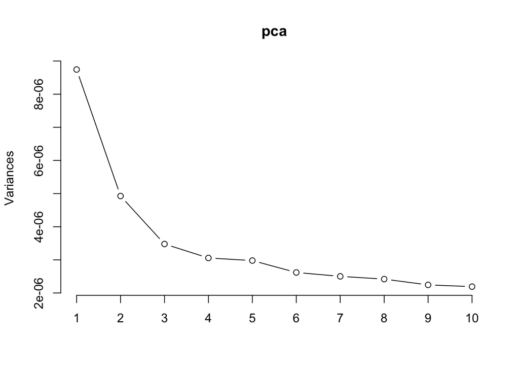

```r
screeplot(pca, type = "l")
```

```r
summary(pca)
```

```
# Importance of components:
#                             PC1     PC2      PC3      PC4      PC5
# Standard deviation     0.002957 0.00222 0.001865 0.001748 0.001726
# Proportion of Variance 0.201440 0.11348 0.080140 0.070410 0.068620
# Cumulative Proportion  0.201440 0.31492 0.395060 0.465470 0.534090
#                             PC6      PC7      PC8      PC9     PC10
# Standard deviation     0.001618 0.001582 0.001555 0.001498 0.001481
# Proportion of Variance 0.060340 0.057650 0.055730 0.051710 0.050500
# Cumulative Proportion  0.594430 0.652080 0.707810 0.759510 0.810010
#                            PC11     PC12     PC13     PC14     PC15
# Standard deviation     0.001413 0.001365 0.001263 0.001191 0.001173
# Proportion of Variance 0.045980 0.042910 0.036760 0.032670 0.031670
# Cumulative Proportion  0.855990 0.898900 0.935660 0.968330 1.000000
#                             PC16
# Standard deviation     5.898e-17
# Proportion of Variance 0.000e+00
# Cumulative Proportion  1.000e+00
```

We plotted the PCA with the first two PC’s which have a Cumulative Proportion of explained variation of ~31%.

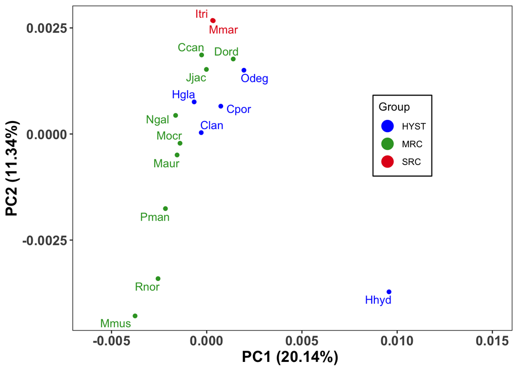

```r
# Plot the PCA
library(ggplot2)
library(ggfortify)
library(ggrepel)

ggplot(data = dat, aes(x = PC1, y = PC2, colour = Group)) + geom_point() + scale_x_continuous(limits = c(-0.006,
    0.015)) + labs(x = "PC1 (20.14%) ", y = "PC2 (11.34%)") + theme(panel.background = element_rect(fill = "white",
    colour = "black"), panel.grid.major = element_blank(), panel.grid.minor = element_blank(),
    axis.text.x = element_text(face = "bold", size = 13), axis.text.y = element_text(face = "bold",
        size = 13), axis.title.y = element_text(face = "bold", size = 15), axis.title.x = element_text(face = "bold",
        size = 15)) + theme(legend.position = c(0.75, 0.6), legend.background = element_rect(color = "black",
    fill = "white", size = 0.5, linetype = "solid")) + geom_text_repel(aes(label = rownames(dat))) +
    theme(legend.key = element_blank()) + scale_color_manual(values = c("Blue", "#33a02c",
    "#e31a1c")) + guides(colour = guide_legend(override.aes = list(size = 5)))
```

### Overrepresentation test (Fisher’s exact test)

We looked at the gene families that were driving Capybara’s genome functional diversification particularly in PC1.

```r
# Only families that lie on the 2.5% tails of the distribution of the loadings

loadings = as.data.frame(pca$rotation)
escogidas_pc1 <- loadings$PC1 >= quantile(loadings$PC1, 0.975) | loadings$PC1 <=
    quantile(loadings$PC1, 0.025)
pc1_importantes <- loadings$PC1[escogidas_pc1]
names <- rownames(loadings)
pc1 <- names[escogidas_pc1]
pc1_edit <- gsub("\\.SF[0-9]+", "", pc1)
avail_panther_fams_edit <- gsub("\\:SF[0-9]+", "", avail_panther_fams)

pc1_fams <- unique(pc1_edit)
fisherPvalues_pc1 <- c()
gene_fam_pc1 <- c()

for (i in 1:length(pc1_fams)) {
    # Perform a Fisher's exact test iteratively for each gene family on the 2.5%
    # tails
    a <- sapply(pc1_fams[i], function(x) sum(x == pc1_edit))
    b <- sapply(pc1_fams[i], function(x) sum(x == avail_panther_fams_edit))
    c <- length(pc1_edit) - a
    d <- length(avail_panther_fams_edit) - b
    f <- fisher.test(matrix(c(a, b, c, d), nrow = 2, ncol = 2, byrow = TRUE), alternative = "greater")
    gene_fam_pc1 <- c(gene_fam_pc1, as.character(pc1_fams[i]))
    fisherPvalues_pc1 <- c(fisherPvalues_pc1, f$p.value)
}

# Bonferroni correction for multiple testing
fisherPvalues_pc1_Bonferroni <- p.adjust(fisherPvalues_pc1, method = "bonferroni",
    n = length(fisherPvalues_pc1))
pc1_fisherResults <- data.frame(gene_fam_pc1, fisherPvalues_pc1, fisherPvalues_pc1_Bonferroni)
significativas_pc1 <- pc1_fisherResults[pc1_fisherResults$fisherPvalues_pc1_Bonferroni <
    0.05, ]

# Gene families driving functional diversification in PC1
pc1_fisherResults[which(pc1_fisherResults$fisherPvalues_pc1_Bonferroni < 0.05), ]
```

|  | gene_fam_pc1 | fisherPvalues_pc1 | fisherPvalues_pc1_Bonferroni |
| --- | --- | --- | --- |
| 22 | PTHR26451 | 5.602269e-13 | 3.389373e-10 |
| 47 | PTHR26452 | 2.024936e-15 | 1.225086e-12 |
| 97 | PTHR26453 | 1.362245e-06 | 8.241585e-04 |
| 159 | PTHR26450 | 6.134195e-05 | 3.711188e-02 |
| 233 | PTHR24061 | 4.549099e-05 | 2.752205e-02 |
| 311 | PTHR23266 | 7.901453e-08 | 4.780379e-05 |
| 330 | PTHR26454 | 2.296969e-05 | 1.389666e-02 |
| 555 | PTHR23267 | 3.482465e-08 | 2.106891e-05 |
| 556 | PTHR23268 | 4.961563e-05 | 3.001745e-02 |